# SingleCellAnalysisWorkshop_2023 Book2

# Single Cell Analysis in R 2023 Notebook 2

This workbook presents the next steps in the basic work flow for scRNAseq analysis 1. Merging samples and batch correction 2. Clustering 3. Cluster annotation 4. Compare proportions of cell types

```r
Sys.time()
```

```
## [1] "2023-05-07 14:48:32 EDT"
```

```r
# load libraries
library(Seurat)
library(tidyverse)
library(enrichR)
```

```r
library(ggplot2)
library("scClassify")
library(SingleCellExperiment)
library("Matrix")
# setwd only works inside the same code chunk
# we can use the GUI to change the working directory for the rest of the workbook
# Session < Set Working Directory < Choose Directory
#
#setwd("C:/Users/Home/Documents/GitHub/SingleCell_Workshop/")
# on mac
setwd("C:/Users/Home/Documents/GitHub/SingleCell_Workshop/")
# put the pathway to your files here


# read in the data objects if starting from save files
adolescent_data_seurat <- readRDS("adolsecentSeurat.Rds") %>% RenameCells(add.cell.id = "Adol_")

adult_data_seurat <- readRDS("adultSeurat.Rds") %>% RenameCells(add.cell.id = "Adult_")
```

Merge data objects

```r
merge_seurat <- merge(adolescent_data_seurat,adult_data_seurat)
merge_seurat
```

```
## An object of class Seurat
## 20116 features across 9044 samples within 1 assay
## Active assay: RNA (20116 features, 0 variable features)
```

```r
unique(merge_seurat$orig.ident)
```

```
## [1] "Adolescent" "Adult"
```

Integrate objects using the Seurat function

```r
sample.list <- SplitObject(merge_seurat, split.by = "orig.ident")

# We have already normalized and identified variable features in each sample
# If we had not done so we can normalize here
#for (i in 1:length(sample.list)){
 # org.list[[i]] <- NormalizeData(org.list[[i]], verbose = FALSE)
  #org.list[[i]] <- FindVariableFeatures(org.list[[i]], selection.method = "vst")
#}

# Now we find features that can act as anchors between the two samples
int.anchors <- FindIntegrationAnchors(object.list = sample.list, dims = 1:50)
```

```
## Computing 2000 integration features
```

```
## No variable features found for object1 in the object.list. Running FindVariableFeatures ...
```

```
## No variable features found for object2 in the object.list. Running FindVariableFeatures ...
```

```
## Scaling features for provided objects
```

```
## Finding all pairwise anchors
```

```
## Running CCA
```

```
## Merging objects
```

```
## Finding neighborhoods
```

```
## Finding anchors
```

```
##  Found 7587 anchors
```

```
## Filtering anchors
```

```
##  Retained 4795 anchors
```

```r
integrated_seurat <- IntegrateData(anchorset = int.anchors, dims = 1:50)
```

```
## Merging dataset 2 into 1
```

```
## Extracting anchors for merged samples
```

```
## Finding integration vectors
```

```
## Finding integration vector weights
```

```
## Integrating data
```

Optional: Save the integrated object or read in the Integrated object for the next step.

```r
# remove # comment from the code you want to run
#saveRDS(integrated_seurat,"IntegratedSeurat.RDS")
#integrated_seurat <- readRDS("IntegratedSeurat.RDS")
```

Perform dimensional reduction PCA and UMAP on the merge and intergrated objects

```r
# first the merge object
DefaultAssay(merge_seurat) <- "RNA"

merge_seurat <- ScaleData(merge_seurat, verbose = FALSE)
# in the merge data set we sill need features for the PCA input
merge_seurat <- FindVariableFeatures(merge_seurat, selection.method = "vst")
merge_seurat <- RunPCA(merge_seurat, npcs = 30, verbose = FALSE)
merge_seurat <- RunUMAP(merge_seurat, reduction = "pca", dims = 1:30)
```

Repeat PCA and UMAP for the integrated object

```r
Idents(integrated_seurat) <- "integrated"
integrated_seurat <- ScaleData(integrated_seurat, verbose = FALSE)
# only the integrated features will be the pca input
integrated_seurat <- RunPCA(integrated_seurat, npcs = 30, verbose = FALSE)
integrated_seurat <- RunUMAP(integrated_seurat, reduction = "pca", dims = 1:30)
```

Optional: save the PCA and UMAP integrated object or read in the saved object

```r
# remove # comment from the code you want to run
#saveRDS(integrated_seurat,"IntegratedSeuratGraphs.RDS")
#integrated_seurat <- readRDS("IntegratedSeuratGraphs.RDS")
```

Visualize the UMAPs comparing the merged and integrated objects

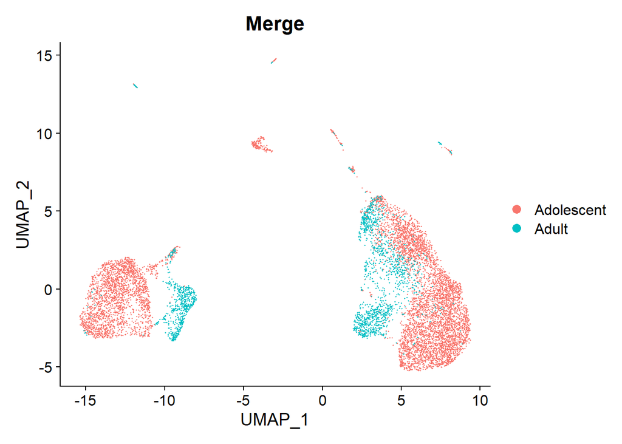

```r
p1 <- DimPlot(merge_seurat, group.by = "orig.ident") + ggtitle("Merge")
p2 <- DimPlot(integrated_seurat, group.by = "orig.ident") + ggtitle("Integrated")

p1
```

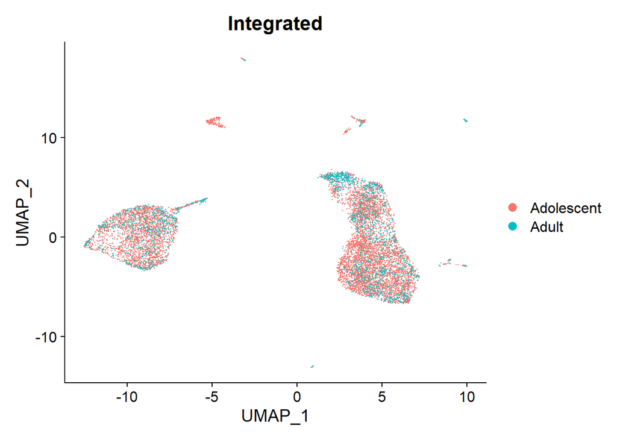

```r
p2
```

We can see a large shift in the two populations when the data is integrated (harmonized).

Cluster the integrated data

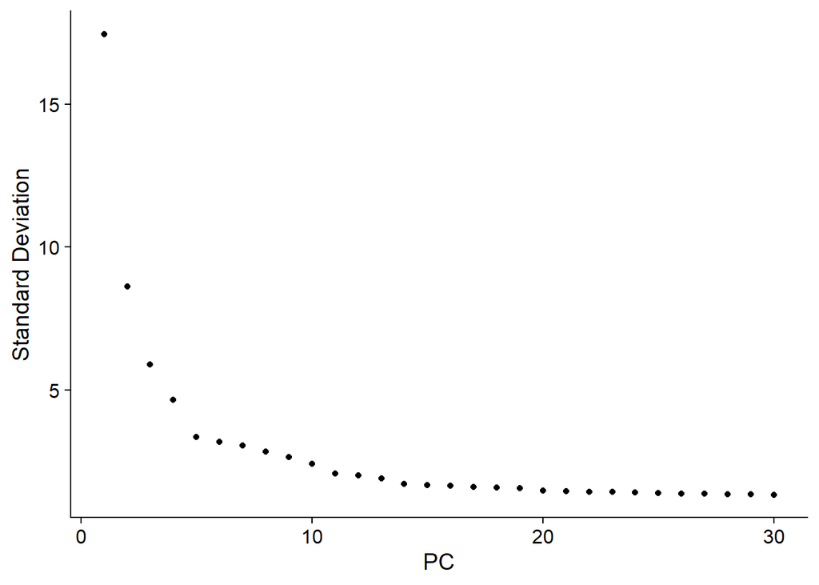

```r
# see the importance of the pca components
ElbowPlot(integrated_seurat, ndims=30)
```

```r
integrated_seurat
```

```
## An object of class Seurat
## 22116 features across 9044 samples within 2 assays
## Active assay: integrated (2000 features, 2000 variable features)
##  1 other assay present: RNA
##  2 dimensional reductions calculated: pca, umap
```

Choose 15 PCs There are 9044 cells. A common rule of thumb for choosing k for nearest neighbours is using the square root of the number of cells = 95

```r
# calculate the square root
sqrt(9044)
```

```
## [1] 95.09995
```

```r
# the K parameter changes the size of clusters by changing the starting nodes input into the Louvain network

integrated_seurat <- FindNeighbors(integrated_seurat, dims = 1:15, k.param = 95)
# the number of clusters is dependent on the resolution a number from 0-2.
# Higher values make more clusters
# we include
integrated_seurat <- FindClusters(integrated_seurat, resolution = c(0,0.05,0.25,0.4,0.5,0.6,1,1.5) )
```

```
## Modularity Optimizer version 1.3.0 by Ludo Waltman and Nees Jan van Eck
##
## Number of nodes: 9044
## Number of edges: 1529080
##
## Running Louvain algorithm...
## Maximum modularity in 10 random starts: 1.0000
## Number of communities: 1
## Elapsed time: 4 seconds
## Modularity Optimizer version 1.3.0 by Ludo Waltman and Nees Jan van Eck
##
## Number of nodes: 9044
## Number of edges: 1529080
##
## Running Louvain algorithm...
## Maximum modularity in 10 random starts: 0.9727
## Number of communities: 3
## Elapsed time: 3 seconds
## Modularity Optimizer version 1.3.0 by Ludo Waltman and Nees Jan van Eck
##
## Number of nodes: 9044
## Number of edges: 1529080
##
## Running Louvain algorithm...
## Maximum modularity in 10 random starts: 0.9067
## Number of communities: 5
## Elapsed time: 3 seconds
## Modularity Optimizer version 1.3.0 by Ludo Waltman and Nees Jan van Eck
##
## Number of nodes: 9044
## Number of edges: 1529080
##
## Running Louvain algorithm...
## Maximum modularity in 10 random starts: 0.8635
## Number of communities: 8
## Elapsed time: 3 seconds
## Modularity Optimizer version 1.3.0 by Ludo Waltman and Nees Jan van Eck
##
## Number of nodes: 9044
## Number of edges: 1529080
```

[output cut: 17 more lines]

```
## Number of edges: 1529080
##
## Running Louvain algorithm...
## Maximum modularity in 10 random starts: 0.7757
## Number of communities: 12
## Elapsed time: 4 seconds
## Modularity Optimizer version 1.3.0 by Ludo Waltman and Nees Jan van Eck
##
## Number of nodes: 9044
## Number of edges: 1529080
##
## Running Louvain algorithm...
## Maximum modularity in 10 random starts: 0.7176
## Number of communities: 15
## Elapsed time: 5 seconds
```

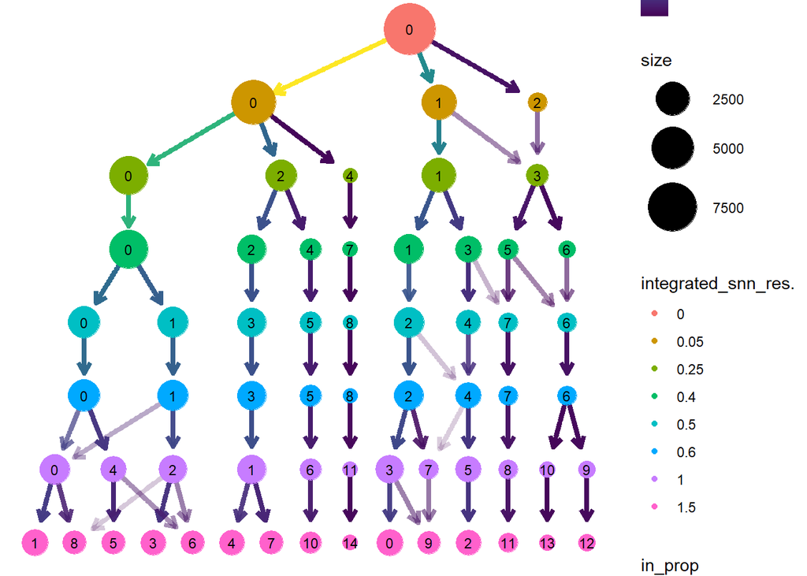

```r
# we can visualize which cells are grouped together at different resolutions using clustree
library(clustree)
clustree(integrated_seurat, prefix = "integrated_snn_res.")
```

Optional: save the clusters or read in the object with clusters

```r
# remove # comment from the code you want to run
#saveRDS(integrated_seurat,"IntegratedSeuratClusters.RDS")
#integrated_seurat <- readRDS("IntegratedSeuratClusters.RDS")
```

Visualize the UMAP of the different cluster resolutions

```r
res <- c(0.05,0.25,0.4,0.5,0.6,1,1.5)
resolutions <- paste("integrated_snn_res.", res, sep="")
resolutions
```

```
## [1] "integrated_snn_res.0.05" "integrated_snn_res.0.25"
## [3] "integrated_snn_res.0.4"  "integrated_snn_res.0.5"
## [5] "integrated_snn_res.0.6"  "integrated_snn_res.1"
## [7] "integrated_snn_res.1.5"
```

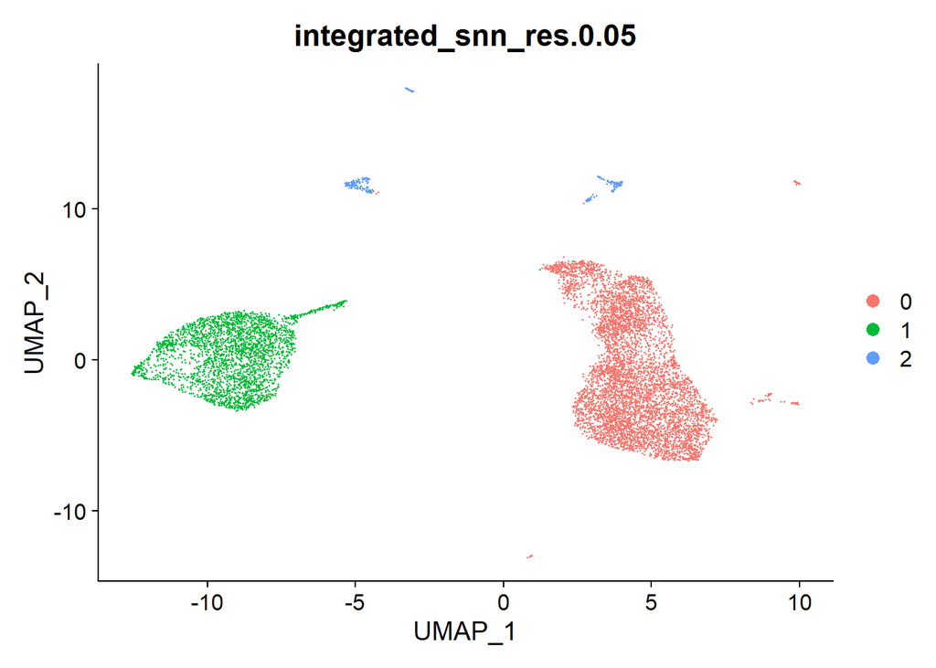

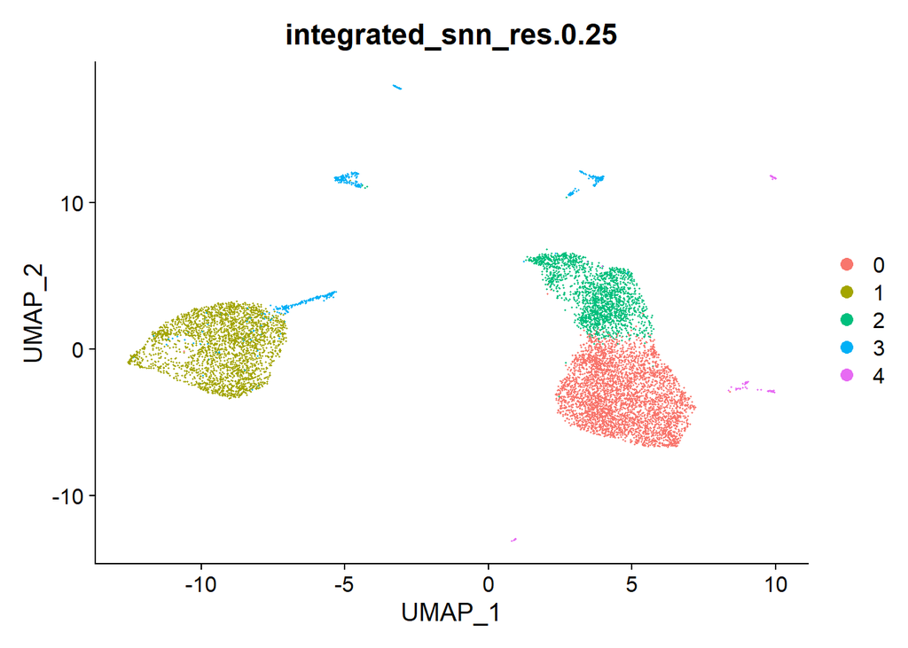

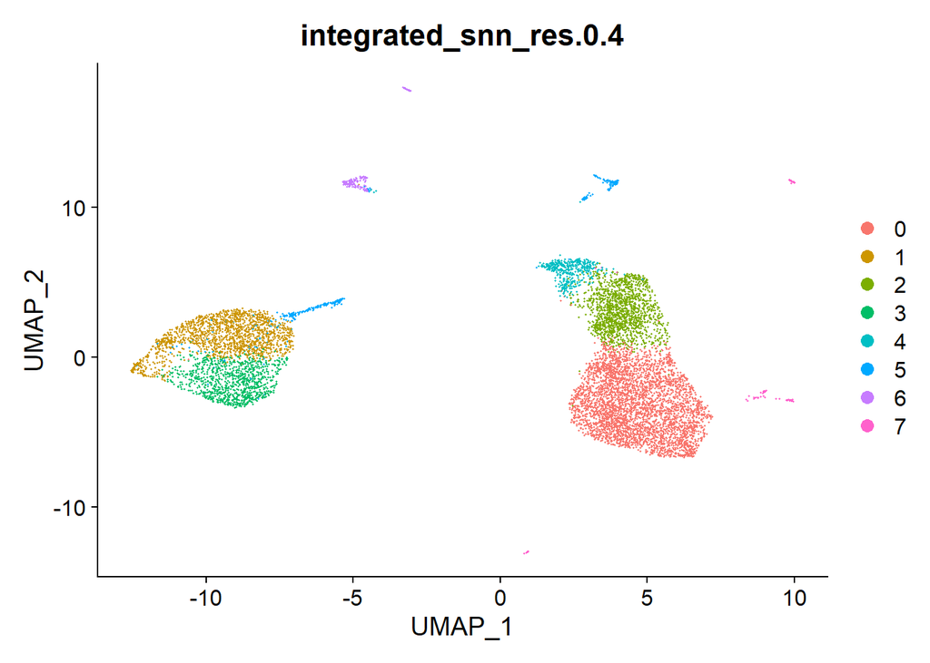

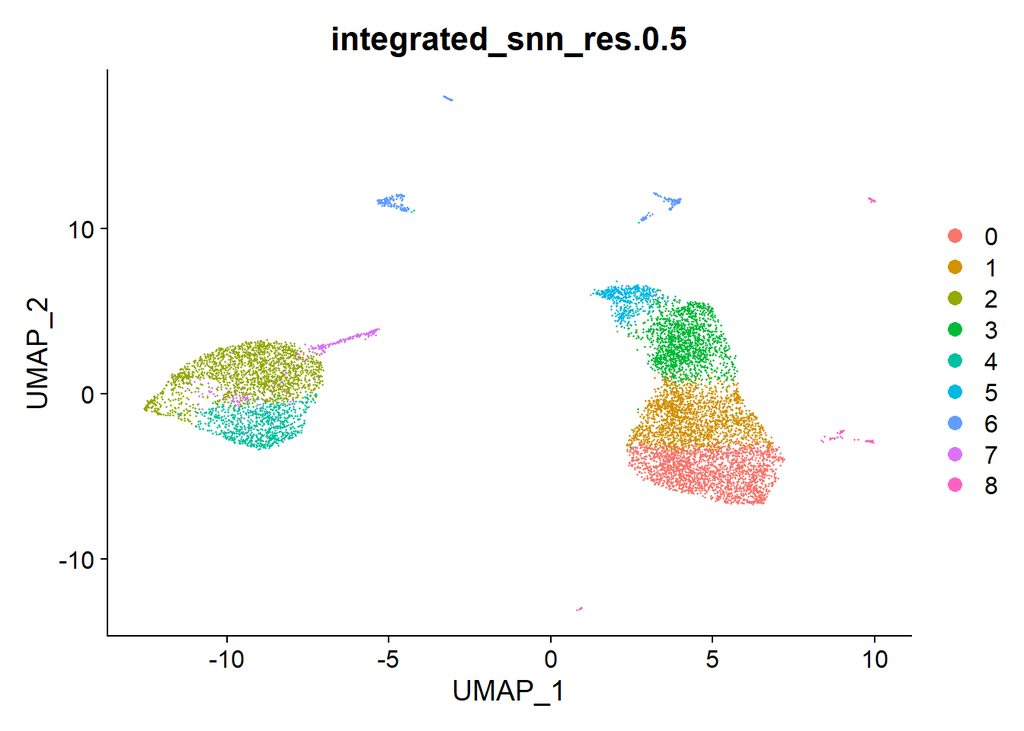

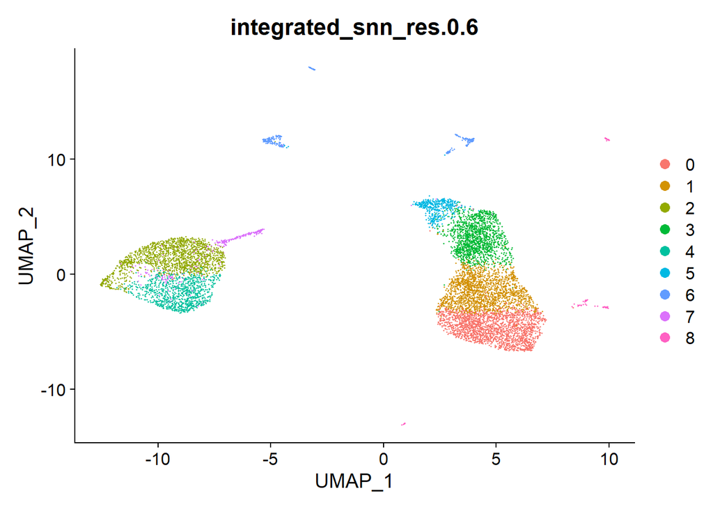

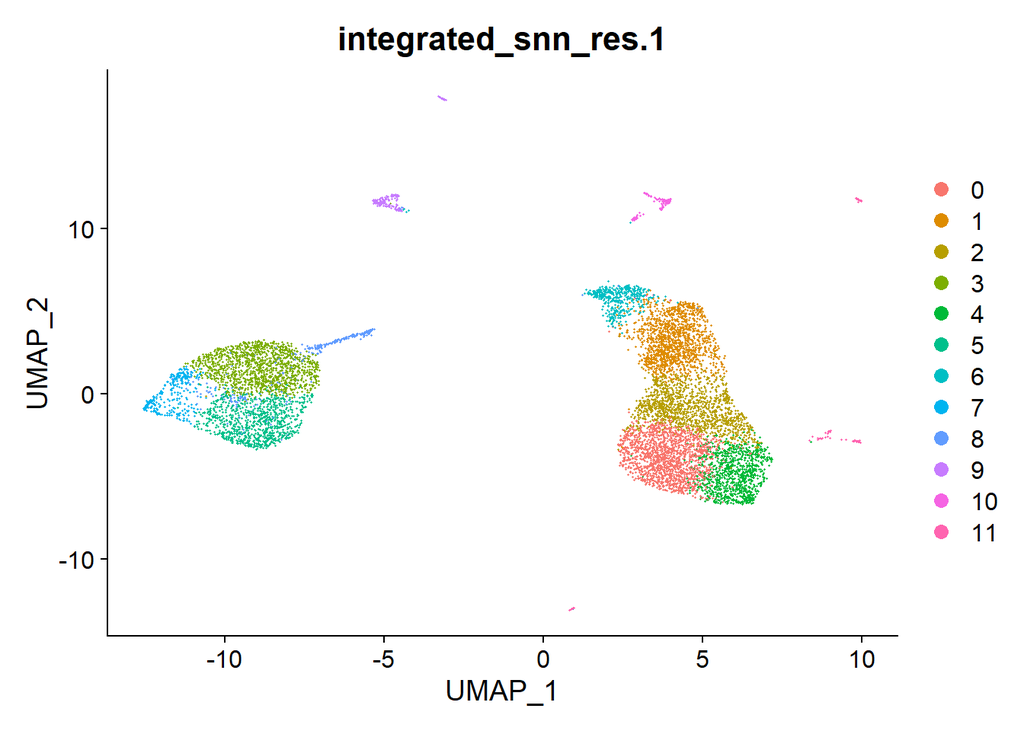

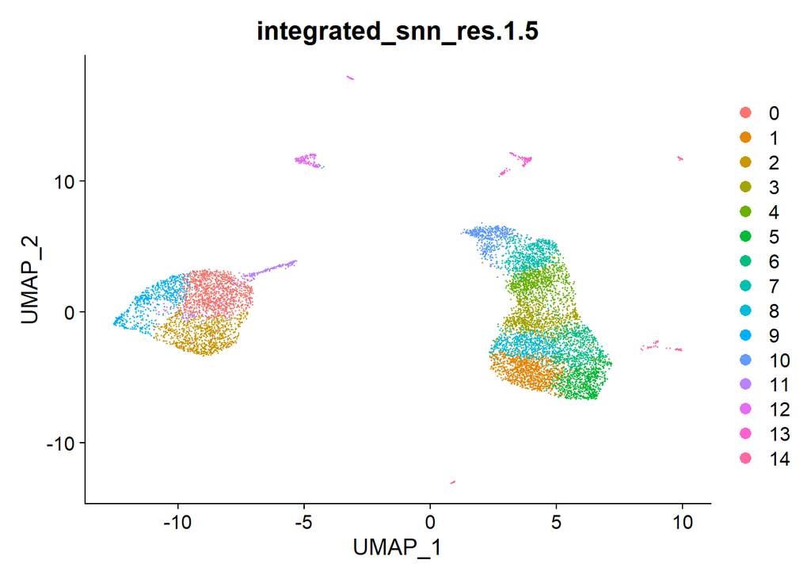

```r
for(r in resolutions){
  print(DimPlot(integrated_seurat, group.by = r))
}
```

Now we choose a resolution to annotate. We are expecting microglia, astrocytes, oligodendrocytes and OPCs. Resolution 0.4 looks like a good amount of clusters.

Cluster annotation

```r
# find cluster markers

# we need to select the level of clustering that we want to annotate
Idents(integrated_seurat) <- "integrated_snn_res.0.4"
ClusterMarkers <- FindAllMarkers(integrated_seurat, only.pos = TRUE)
# optional: save the cluster markers
write.csv(ClusterMarkers,"ClusterMarkers.csv")
```

Optional: If cluster markers were run previously and saved or if they take too long to run, read in the csv

```r
ClusterMarkers <- read.csv("ClusterMarkers.csv")
```

Lets look at the markers to see if they identify cell types

```r
head(ClusterMarkers)
```

|  | X | p_val | avg_log2FC | pct.1 | pct.2 | p_val_adj | cluster | gene |
| --- | --- | --- | --- | --- | --- | --- | --- | --- |
| 1 | CCL3L1 | 0 | 3.606748 | 0.791 | 0.398 | 0 | 0 | CCL3L1 |
| 2 | CCL3 | 0 | 3.434911 | 0.880 | 0.468 | 0 | 0 | CCL3 |
| 3 | CCL4 | 0 | 3.282586 | 0.698 | 0.410 | 0 | 0 | CCL4 |
| 4 | CCL4L2 | 0 | 3.118026 | 0.694 | 0.398 | 0 | 0 | CCL4L2 |
| 5 | GRASP | 0 | 2.939821 | 0.818 | 0.229 | 0 | 0 | GRASP |
| 6 | CD83 | 0 | 2.899081 | 0.925 | 0.254 | 0 | 0 | CD83 |

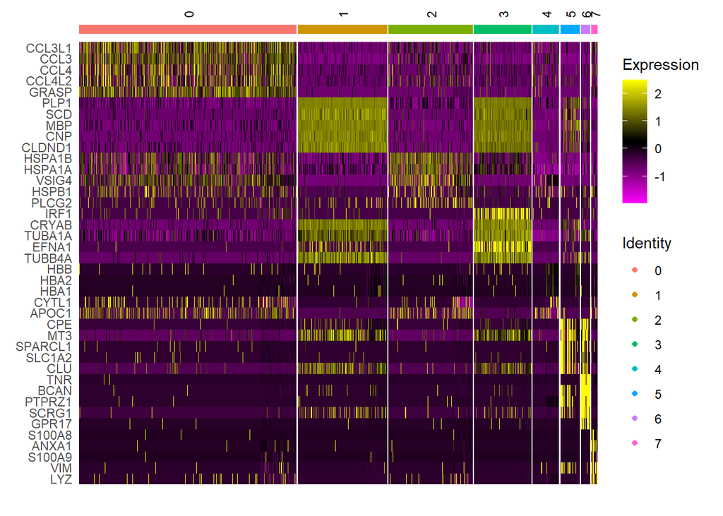

```r
top5 <- ClusterMarkers %>% group_by(cluster) %>% top_n(n=5, wt =avg_log2FC)
DoHeatmap(integrated_seurat, features = top5$gene, size = 3, angle = 90, group.by = "integrated_snn_res.0.4")
```

We can look at the markers for each cluster using Gene set analysis or cell type libraries

```r
setEnrichrSite("Enrichr") # Human genes
```

```
## Connection changed to https://maayanlab.cloud/Enrichr/
```

```
## Connection is Live!
```

```r
# list of all the databases

dbs <- listEnrichrDbs()

# this will list the possible libraries
dbs
```

| geneCoverage | genesPerTerm | libraryName | link | numTerms | appyter | categoryId |
| --- | --- | --- | --- | --- | --- | --- |
| 13362 | 275 | Genome_Browser_PWMs | http://hgdownload.cse.ucsc.edu/goldenPath/hg18/database/ | 615 | ea115789fcbf12797fd692cec6df0ab4dbc79c6a | 1 |
| 27884 | 1284 | TRANSFAC_and_JASPAR_PWMs | http://jaspar.genereg.net/html/DOWNLOAD/ | 326 | 7d42eb43a64a4e3b20d721fc7148f685b53b6b30 | 1 |
| 6002 | 77 | Transcription_Factor_PPIs |  | 290 | 849f222220618e2599d925b6b51868cf1dab3763 | 1 |
| 47172 | 1370 | ChEA_2013 | http://amp.pharm.mssm.edu/lib/cheadownload.jsp | 353 | 7ebe772afb55b63b41b79dd8d06ea0fdd9fa2630 | 7 |
| 47107 | 509 | Drug_Perturbations_from_GEO_2014 | http://www.ncbi.nlm.nih.gov/geo/ | 701 | ad270a6876534b7cb063e004289dcd4d3164f342 | 7 |
| 21493 | 3713 | ENCODE_TF_ChIP-seq_2014 | http://genome.ucsc.edu/ENCODE/downloads.html | 498 | 497787ebc418d308045efb63b8586f10c526af51 | 7 |
| 1295 | 18 | BioCarta_2013 | https://cgap.nci.nih.gov/Pathways/BioCarta_Pathways | 249 | 4a293326037a5229aedb1ad7b2867283573d8bcd | 7 |
| 3185 | 73 | Reactome_2013 | http://www.reactome.org/download/index.html | 78 | b343994a1b68483b0122b08650201c9b313d5c66 | 7 |
| 2854 | 34 | WikiPathways_2013 | http://www.wikipathways.org/index.php/Download_Pathways | 199 | 5c307674c8b97e098f8399c92f451c0ff21cbf68 | 7 |
| 15057 | 300 | Disease_Signatures_from_GEO_up_2014 | http://www.ncbi.nlm.nih.gov/geo/ | 142 | 248c4ed8ea28352795190214713c86a39fd7afab | 7 |

[output cut: 201 more lines]

```r
# select libraries with cell types
db <- c('CellMarker_Augmented_2021','Azimuth_Cell_Types_2021')
```

Here is a small function to run easily on each cluster and find the cell type library predictions

```r
checkCelltypes <- function(cluster_num = 0){
  clusterX <- ClusterMarkers %>% filter(cluster == cluster_num & avg_log2FC > 0.25)
  genes <- clusterX$gene
  # the cell type libraries
  # get the results for each library
  clusterX.cell <- enrichr(genes, databases = db)
  # visulize the results
print(plotEnrich(clusterX.cell[[1]], showTerms = 20, numChar = 40, y = "Count", orderBy = "P.value", title = 'CellMarker_Augmented_2021'))
print(plotEnrich(clusterX.cell[[2]], showTerms = 20, numChar = 40, y = "Count", orderBy = "P.value", title = 'Azimuth_Cell_Types_2021'))

}
```

Run the function for each cluster to see if we can identify cell types

```r
cluster0 <- checkCelltypes(cluster_num = 0)
```

```
## Uploading data to Enrichr... Done.
##   Querying CellMarker_Augmented_2021... Done.
##   Querying Azimuth_Cell_Types_2021... Done.
## Parsing results... Done.
```

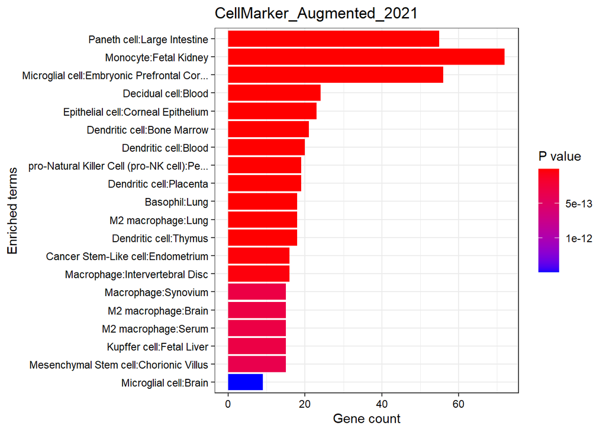

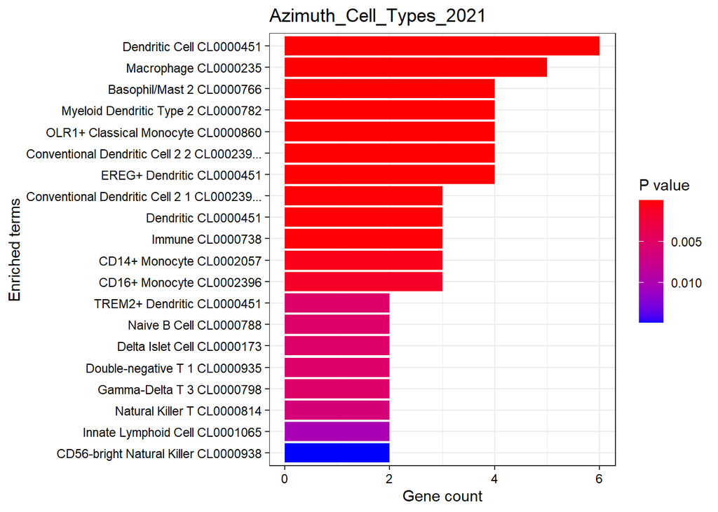

Cluster 0 is some kind of immune cells, possibly dendritic cell or macrophage. These are likely the microglia

```r
cluster1 <- checkCelltypes(cluster_num = 1)
```

```
## Uploading data to Enrichr... Done.
##   Querying CellMarker_Augmented_2021... Done.
##   Querying Azimuth_Cell_Types_2021... Done.
## Parsing results... Done.
```

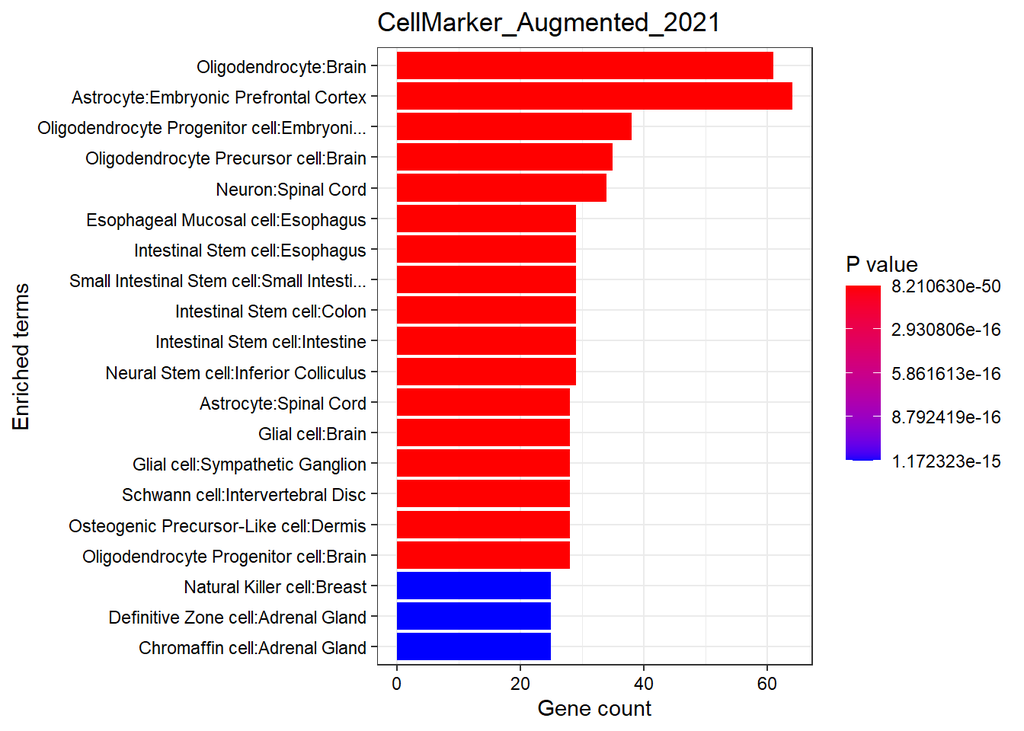

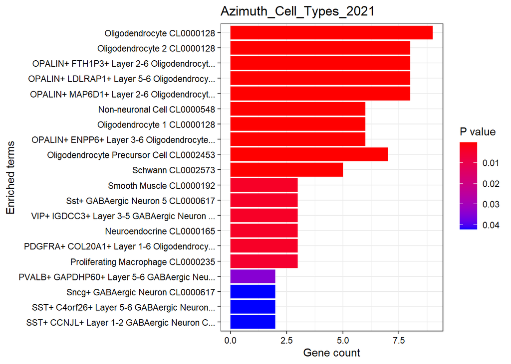

Cluster 1 appears to have oligodendrocytes

```r
cluster2 <- checkCelltypes(cluster_num = 2)
```

```
## Uploading data to Enrichr... Done.
##   Querying CellMarker_Augmented_2021... Done.
##   Querying Azimuth_Cell_Types_2021... Done.
## Parsing results... Done.
```

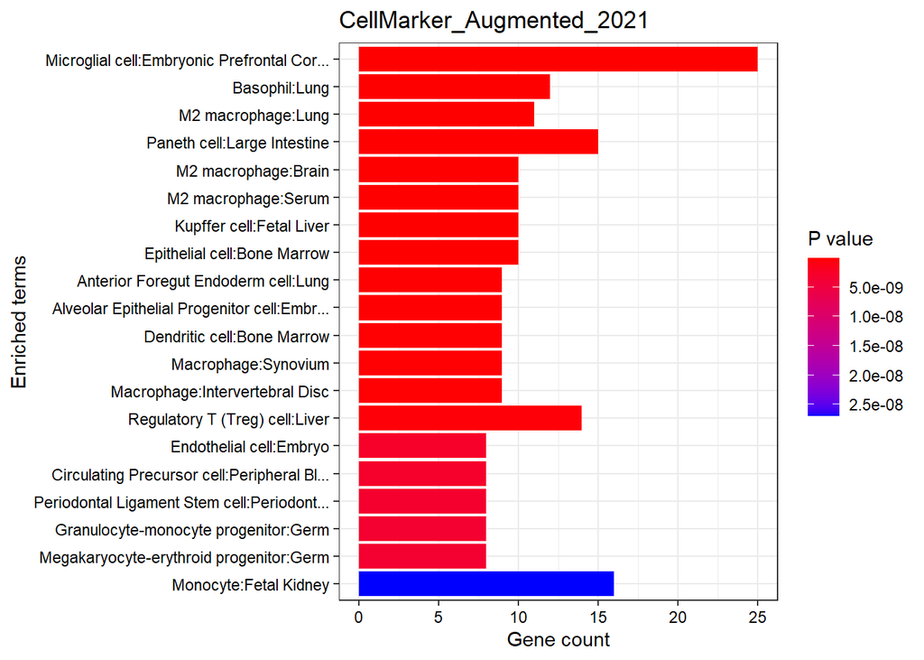

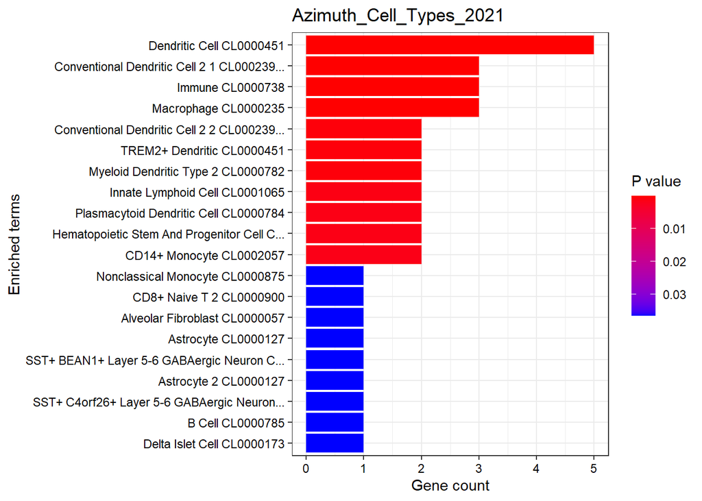

Cluster 2 is also immune cells, embryonic microglia.

```r
# cluster 3
cluster3 <- checkCelltypes(cluster_num = 3)
```

```
## Uploading data to Enrichr... Done.
##   Querying CellMarker_Augmented_2021... Done.
##   Querying Azimuth_Cell_Types_2021... Done.
## Parsing results... Done.
```

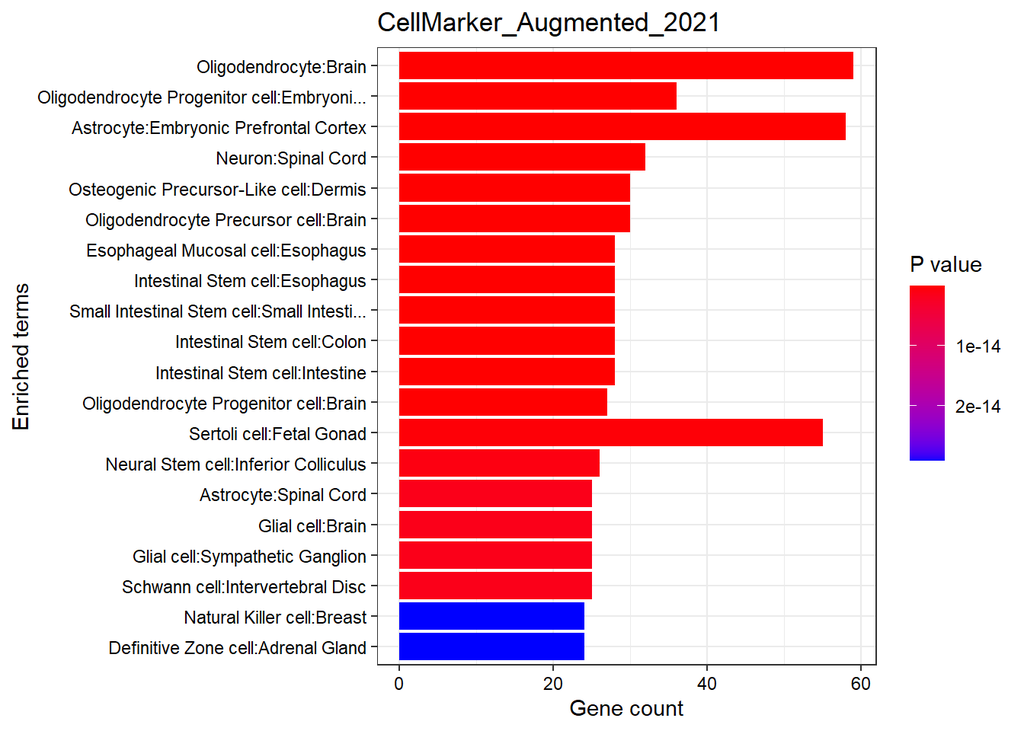

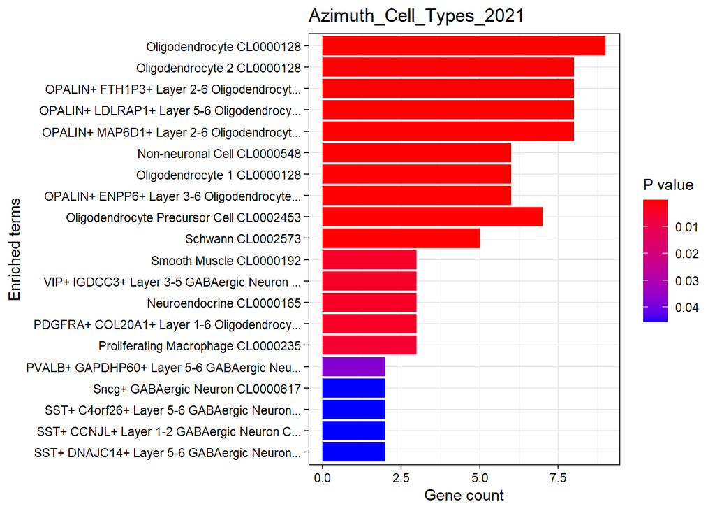

Cluster 3 is oligodendrocytes

```r
# cluster 4
cluster4 <- checkCelltypes(cluster_num = 4)
```

```
## Uploading data to Enrichr... Done.
##   Querying CellMarker_Augmented_2021... Done.
##   Querying Azimuth_Cell_Types_2021... Done.
## Parsing results... Done.
```

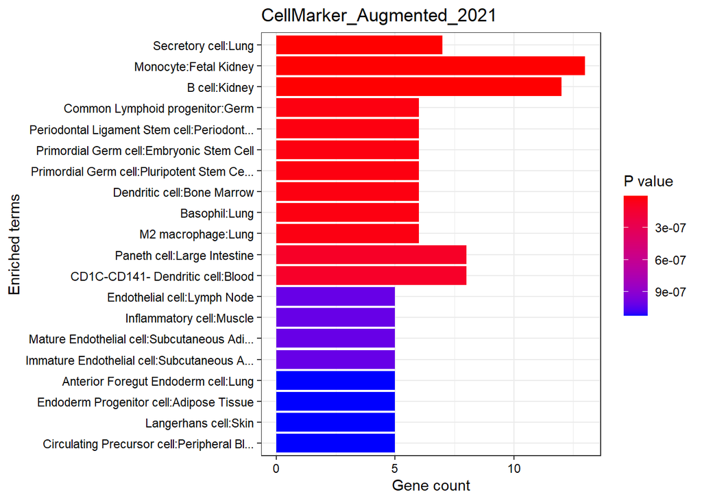

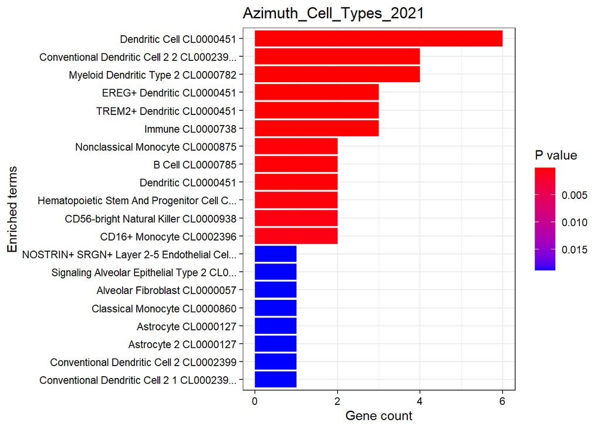

Cluster 4 - immune cells

```r
# cluster 5
cluster5 <- checkCelltypes(cluster_num = 5)
```

```
## Uploading data to Enrichr... Done.
##   Querying CellMarker_Augmented_2021... Done.
##   Querying Azimuth_Cell_Types_2021... Done.
## Parsing results... Done.
```

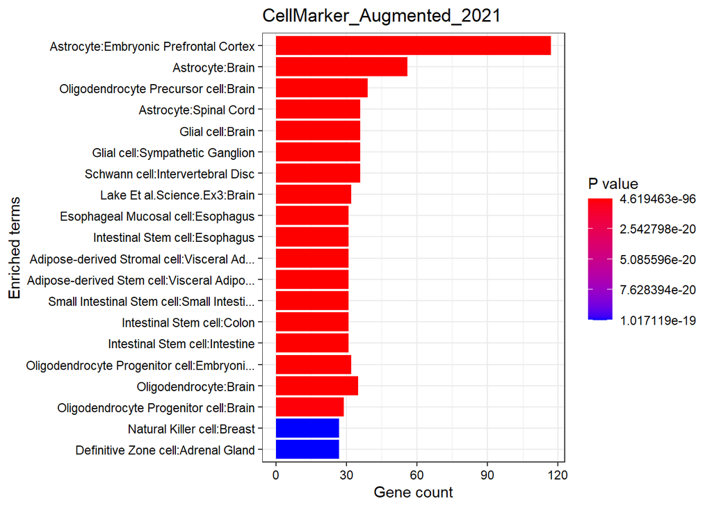

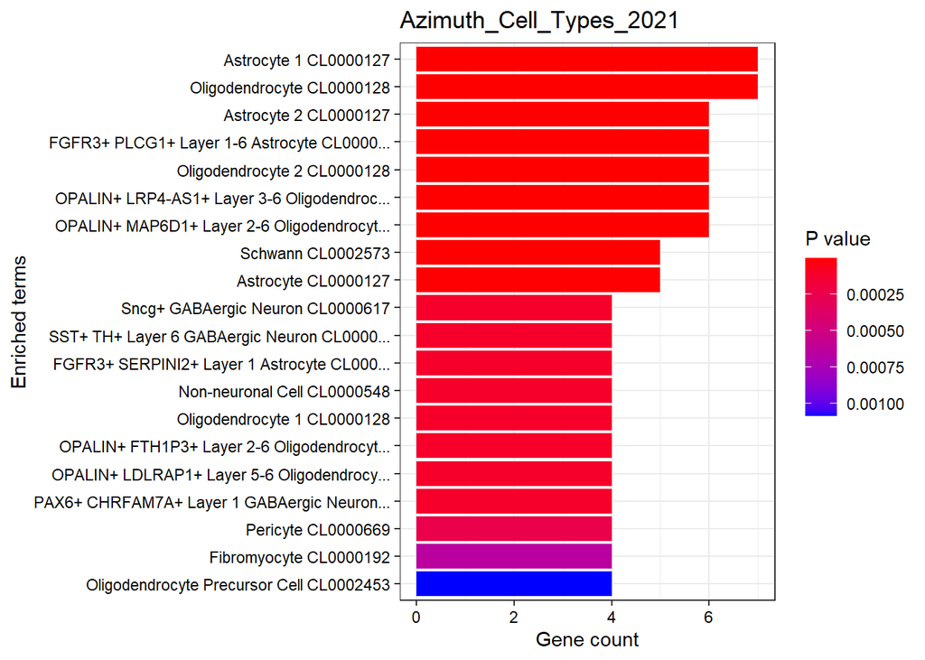

Cluster 5 is astrocytes

```r
# cluster 6
cluster6 <- checkCelltypes(cluster_num = 6)
```

```
## Uploading data to Enrichr... Done.
##   Querying CellMarker_Augmented_2021... Done.
##   Querying Azimuth_Cell_Types_2021... Done.
## Parsing results... Done.
```

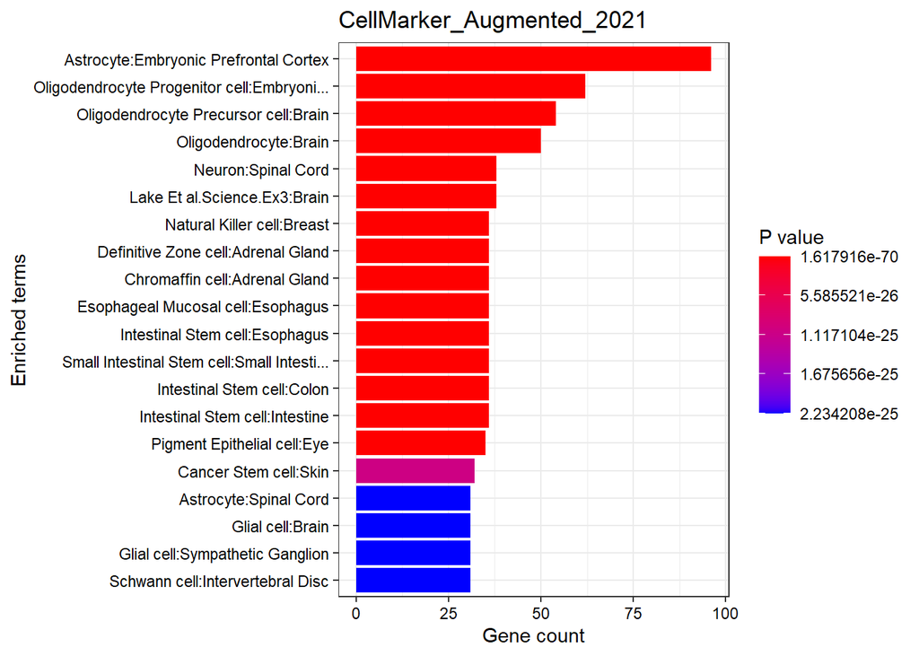

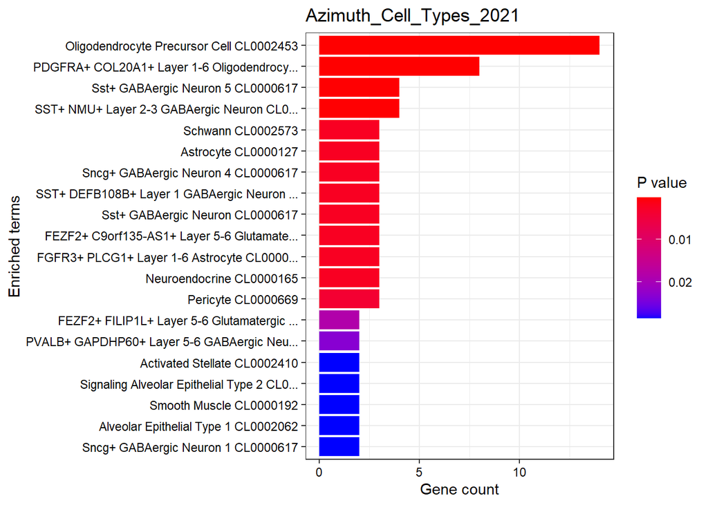

Cluster 6 is OPCs

```r
# cluster 7
cluster7 <- checkCelltypes(cluster_num = 7)
```

```
## Uploading data to Enrichr... Done.
##   Querying CellMarker_Augmented_2021... Done.
##   Querying Azimuth_Cell_Types_2021... Done.
## Parsing results... Done.
```

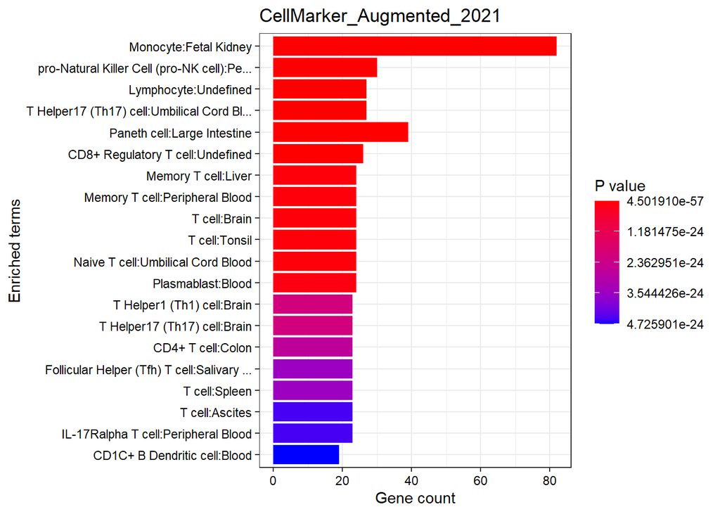

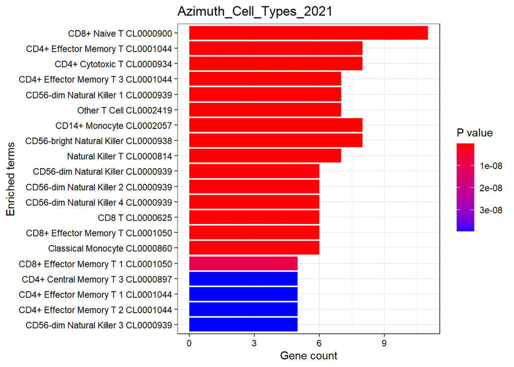

Cluster 7 - monocytes or Tcells

We can remove the lists of cell library outputs to clean up our work environment

```r
rm(cluster0,cluster1,cluster2,cluster3,cluster4,cluster5,cluster6,cluster7)
```

Looking at known cell type markers is another way to identify cell types

```r
# marker lists

#  doi: 10.1002/glia.23767
microglia <- c("IBA1","P2RY12","P2RY13","TREM119", "GPR34","SIGLECH","TREM2",
               "CX3CR1","FCRLS","OLFML3","HEXB","TGFBR1", "SALL1","MERTK",
               "PROS1")


oligodendrocyte <- c("MBP","MOG","OLIG1","OLIG2","SOX10")

# doi: 10.3390/biom11091361
astrocytes <- c("GFAP","S100B","AQP4","APOE", "SOX9")
```

Look at the expression of different marker lists

```r
# we want to use the total RNA not just the genes that are integrated
# change the default assay
DefaultAssay(integrated_seurat) <- "RNA"
# we need to scale the RNA data
integrated_seurat <- ScaleData(integrated_seurat)
```

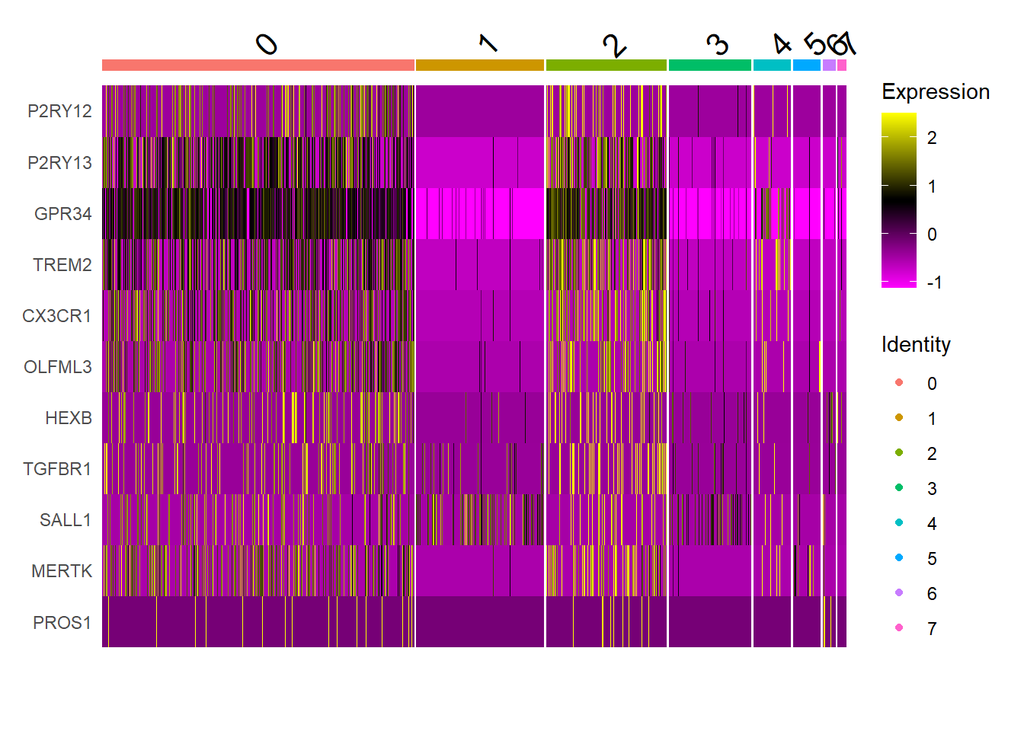

```r
DoHeatmap(integrated_seurat, features = microglia, group.by = "integrated_snn_res.0.4")
```

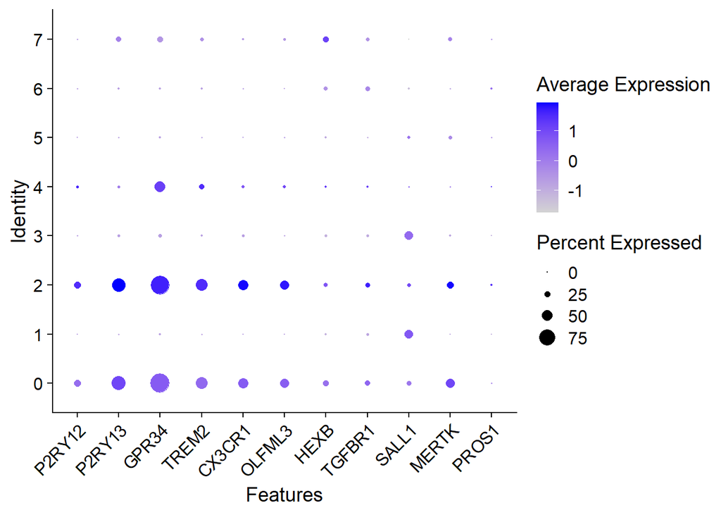

```r
DotPlot(integrated_seurat, features = microglia, group.by = "integrated_snn_res.0.4") + RotatedAxis()
```

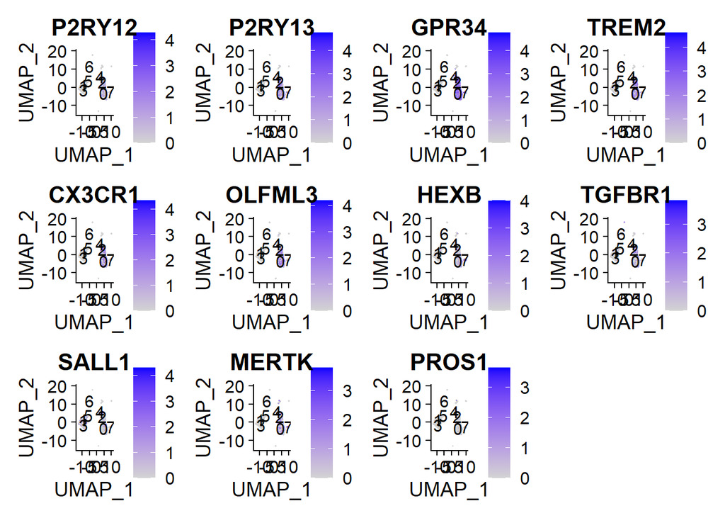

```r
Idents(integrated_seurat) <- "integrated_snn_res.0.4"
FeaturePlot(integrated_seurat, features = microglia, label = TRUE)
```

Cluster 0 has some microglial markers and cluster 2 has lots of microglia markers.

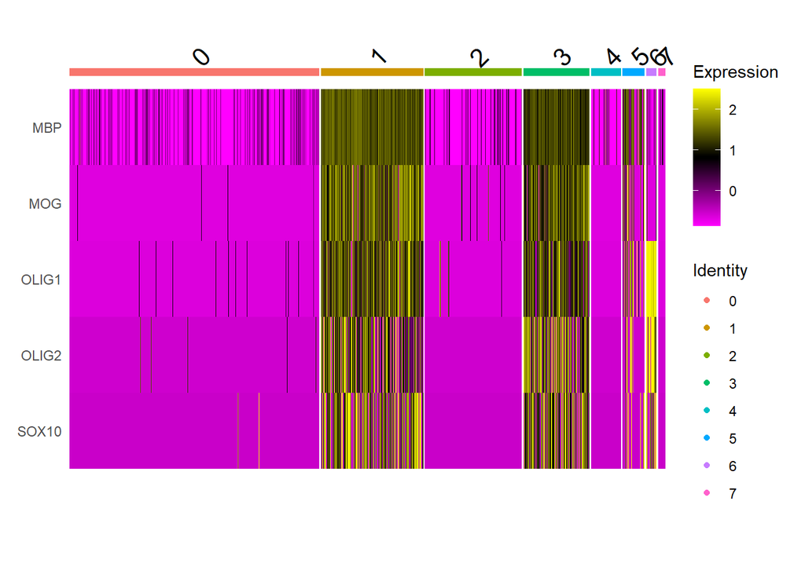

```r
# oligodendrocytes
DoHeatmap(integrated_seurat, features = oligodendrocyte, group.by = "integrated_snn_res.0.4")
```